# Analisis dan Pemodelan: Dataset Voting Anggota Kongres AS

### Sumber data

dataset diambil dari link dibawah ini: https://archive.ics.uci.edu/dataset/105/congressional+voting+records

Tujuan:

1. Melakukan pembersihan dan eksplorasi data untuk memahami pola voting.
2. Membangun model Klasifikasi untuk memprediksi afiliasi partai (democrat/republican) berdasarkan riwayat voting.
3. Membangun model Clustering untuk menemukan kelompok-kelompok legislator dengan pola voting serupa, terlepas dari partainya.

## 1. Impor Library

Langkah pertama adalah mengimpor semua library Python yang akan kita butuhkan untuk analisis ini.

```python
# Untuk manipulasi data
import pandas as pd
import numpy as np

# Untuk visualisasi data
import matplotlib.pyplot as plt
import seaborn as sns

# Untuk pemodelan machine learning
from sklearn.model_selection import train_test_split
from sklearn.linear_model import LogisticRegression
from sklearn.cluster import KMeans
from sklearn.metrics import accuracy_score, classification_report, confusion_matrix

# Mengatur agar plot ditampilkan di dalam notebook
%matplotlib inline

# Mengatur style visualisasi
sns.set_style('whitegrid')
```

## 2. Memuat Data

Kita akan memuat dataset langsung dari URL repositori UCI. Dataset ini tidak memiliki header (nama kolom), jadi kita akan mendefinisikannya secara manual sesuai dengan dokumentasi. Nilai yang hilang ditandai dengan karakter ?.

```python
# Definisikan URL dan nama kolom
url = 'https://archive.ics.uci.edu/ml/machine-learning-databases/voting-records/house-votes-84.data'
columns = [
    'class_name', 'handicapped_infants', 'water_project', 'budget_resolution', 'physician_fee_freeze',
    'el_salvador_aid', 'religious_groups_in_schools', 'anti_satellite_test_ban', 'aid_to_nicaraguan_contras',
    'mx_missile', 'immigration', 'synfuels_corporation_cutback', 'education_spending', 'superfund_right_to_sue',
    'crime', 'duty_free_exports', 'export_administration_act_south_africa'
]

# Baca data, tandai '?' sebagai nilai hilang (NaN)
df = pd.read_csv(url, header=None, names=columns, na_values='?')

print("5 baris pertama dari dataset:")
display(df.head())

print("\nInformasi dasar dataset:")
df.info()
```

```
5 baris pertama dari dataset:
```

|  | class_name | handicapped_infants | water_project | budget_resolution | physician_fee_freeze | el_salvador_aid | religious_groups_in_schools | anti_satellite_test_ban | aid_to_nicaraguan_contras | mx_missile | immigration | synfuels_corporation_cutback | education_spending | superfund_right_to_sue | crime | duty_free_exports | export_administration_act_south_africa |
| --- | --- | --- | --- | --- | --- | --- | --- | --- | --- | --- | --- | --- | --- | --- | --- | --- | --- |
| 0 | republican | n | y | n | y | y | y | n | n | n | y | NaN | y | y | y | n | y |
| 1 | republican | n | y | n | y | y | y | n | n | n | n | n | y | y | y | n | NaN |
| 2 | democrat | NaN | y | y | NaN | y | y | n | n | n | n | y | n | y | y | n | n |
| 3 | democrat | n | y | y | n | NaN | y | n | n | n | n | y | n | y | n | n | y |
| 4 | democrat | y | y | y | n | y | y | n | n | n | n | y | NaN | y | y | y | y |

```
Informasi dasar dataset:
<class 'pandas.core.frame.DataFrame'>
RangeIndex: 435 entries, 0 to 434
Data columns (total 17 columns):
 #   Column                                  Non-Null Count  Dtype
---  ------                                  --------------  -----
 0   class_name                              435 non-null    object
 1   handicapped_infants                     423 non-null    object
 2   water_project                           387 non-null    object
 3   budget_resolution                       424 non-null    object
 4   physician_fee_freeze                    424 non-null    object
 5   el_salvador_aid                         420 non-null    object
 6   religious_groups_in_schools             424 non-null    object
 7   anti_satellite_test_ban                 421 non-null    object
 8   aid_to_nicaraguan_contras               420 non-null    object
 9   mx_missile                              413 non-null    object
 10  immigration                             428 non-null    object
 11  synfuels_corporation_cutback            414 non-null    object
 12  education_spending                      404 non-null    object
 13  superfund_right_to_sue                  410 non-null    object
 14  crime                                   418 non-null    object
 15  duty_free_exports                       407 non-null    object
 16  export_administration_act_south_africa  331 non-null    object
dtypes: object(17)
memory usage: 57.9+ KB
```

## 3. Pembersihan dan Pra-pemrosesan Data

Tahap ini krusial untuk memastikan kualitas data sebelum dianalisis dan dimodelkan.

### 3.1. Menangani Nilai Hilang (Missing Values)

Nilai ? (sekarang NaN) menandakan seorang legislator tidak memberikan suara. Kita perlu mengisi nilai-nilai ini. Karena datanya kategorikal (y/n), strategi terbaik adalah menggunakan modus (nilai yang paling sering muncul) dari setiap kolom.

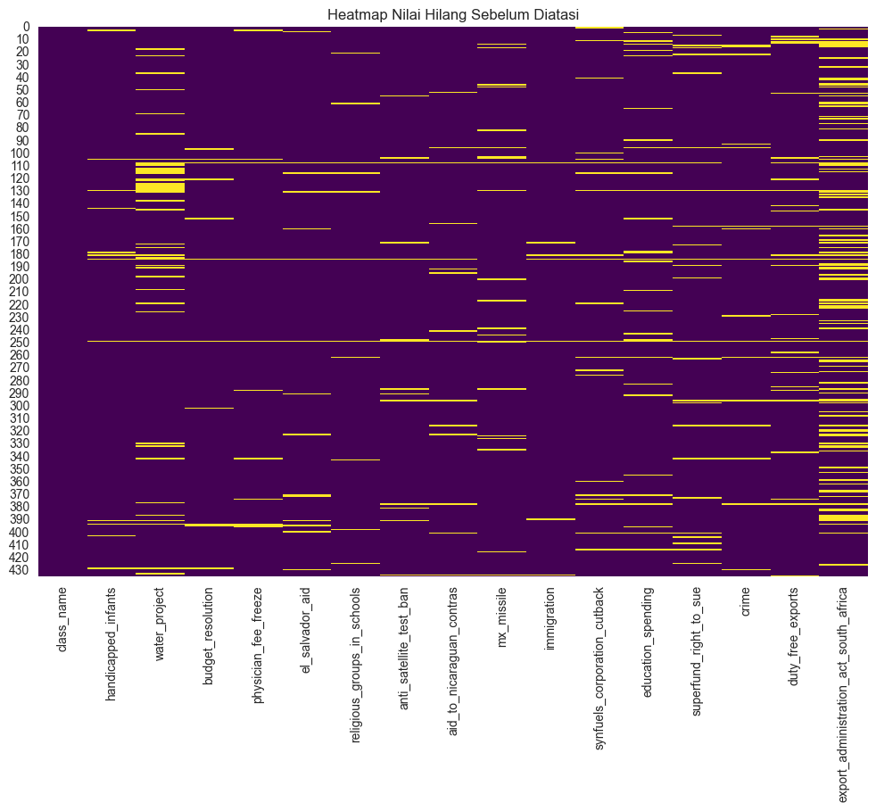

```
Mengisi nilai yang hilang dengan modus...

Jumlah nilai hilang setelah diatasi: 0
```

[output not shown]

```python
# Visualisasi nilai hilang dengan heatmap
plt.figure(figsize=(12, 8))
sns.heatmap(df.isnull(), cbar=False, cmap='viridis')
plt.title('Heatmap Nilai Hilang Sebelum Diatasi')
plt.show()

# Mengisi nilai NaN dengan modus dari setiap kolom
print("Mengisi nilai yang hilang dengan modus...")
for col in df.columns:
    if df[col].isnull().any():
        # [0] digunakan karena modus bisa mengembalikan lebih dari satu nilai
        mode_value = df[col].mode()[0]
        df[col].fillna(mode_value, inplace=True)

# Verifikasi bahwa tidak ada lagi nilai yang hilang
print("\nJumlah nilai hilang setelah diatasi:", df.isnull().sum().sum())
```

### 3.2. Transformasi Data

Model machine learning membutuhkan input numerik. Kita akan mengubah semua nilai kategorikal (y, n, democrat, republican) menjadi angka (1, 0).

```python
# Buat salinan dataframe untuk transformasi
df_transformed = df.copy()

# Ganti semua nilai 'y' menjadi 1 dan 'n' menjadi 0
for col in df_transformed.columns[1:]: # Mulai dari kolom kedua (voting)
    df_transformed[col] = df_transformed[col].map({'y': 1, 'n': 0})

# Ganti nilai 'democrat' menjadi 1 dan 'republican' menjadi 0
df_transformed['class_name'] = df_transformed['class_name'].map({'democrat': 1, 'republican': 0})

print("5 baris pertama dari data yang sudah ditransformasi:")
display(df_transformed.head())
```

```
5 baris pertama dari data yang sudah ditransformasi:
```

|  | class_name | handicapped_infants | water_project | budget_resolution | physician_fee_freeze | el_salvador_aid | religious_groups_in_schools | anti_satellite_test_ban | aid_to_nicaraguan_contras | mx_missile | immigration | synfuels_corporation_cutback | education_spending | superfund_right_to_sue | crime | duty_free_exports | export_administration_act_south_africa |
| --- | --- | --- | --- | --- | --- | --- | --- | --- | --- | --- | --- | --- | --- | --- | --- | --- | --- |
| 0 | 0 | 0 | 1 | 0 | 1 | 1 | 1 | 0 | 0 | 0 | 1 | 0 | 1 | 1 | 1 | 0 | 1 |
| 1 | 0 | 0 | 1 | 0 | 1 | 1 | 1 | 0 | 0 | 0 | 0 | 0 | 1 | 1 | 1 | 0 | 1 |
| 2 | 1 | 0 | 1 | 1 | 0 | 1 | 1 | 0 | 0 | 0 | 0 | 1 | 0 | 1 | 1 | 0 | 0 |
| 3 | 1 | 0 | 1 | 1 | 0 | 1 | 1 | 0 | 0 | 0 | 0 | 1 | 0 | 1 | 0 | 0 | 1 |
| 4 | 1 | 1 | 1 | 1 | 0 | 1 | 1 | 0 | 0 | 0 | 0 | 1 | 0 | 1 | 1 | 1 | 1 |

## 4. Analisis Data Eksploratif (EDA)

Mari kita visualisasikan data untuk mendapatkan wawasan.

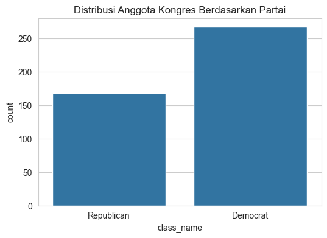

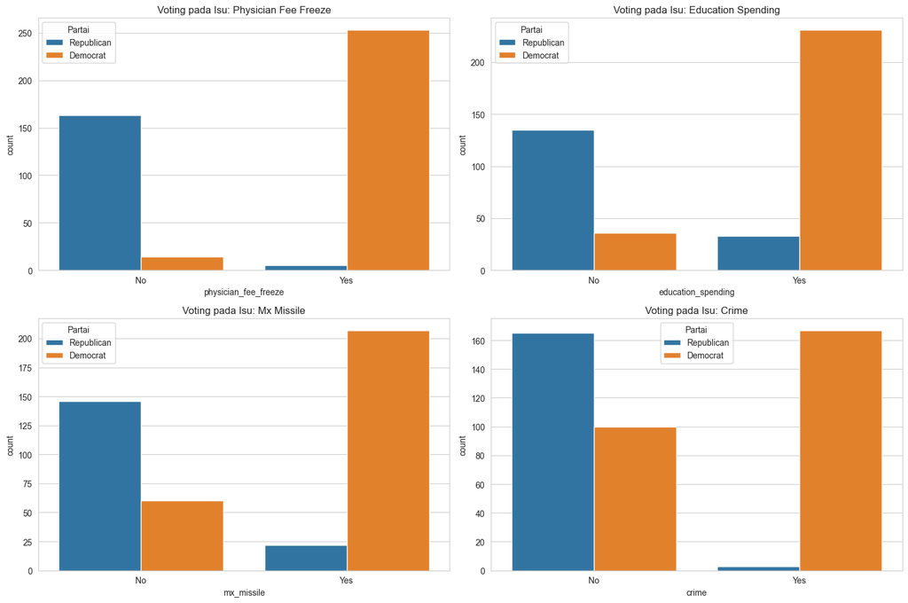

```python
# Visualisasi distribusi partai
plt.figure(figsize=(6, 4))
sns.countplot(x='class_name', data=df)
plt.title('Distribusi Anggota Kongres Berdasarkan Partai')
plt.xticks([0, 1], ['Republican', 'Democrat'])
plt.show()

# Visualisasi voting untuk beberapa isu kunci, dipisahkan berdasarkan partai
plt.figure(figsize=(15, 10))
issues_to_plot = ['physician_fee_freeze', 'education_spending', 'mx_missile', 'crime']
for i, issue in enumerate(issues_to_plot, 1):
    plt.subplot(2, 2, i)
    sns.countplot(x=issue, hue='class_name', data=df)
    plt.title(f'Voting pada Isu: {issue.replace("_", " ").title()}')
    plt.xticks([0, 1], ['No', 'Yes'])
    plt.legend(title='Partai', labels=['Republican', 'Democrat'])
plt.tight_layout()
plt.show()
```

Wawasan dari EDA: Dari plot di atas, kita bisa melihat isu-isu mana yang sangat partisan (pilihan suara sangat berbeda antara kedua partai) dan mana yang lebih bipartisan.

## 5. Pemodelan - Klasifikasi

Tujuan: Membangun model yang dapat memprediksi partai (class_name) seorang legislator berdasarkan 16 hasil votingnya.

```
Akurasi Model Klasifikasi: 0.9540229885057471

Laporan Klasifikasi:
               precision    recall  f1-score   support

  Republican       0.94      0.94      0.94        34
    Democrat       0.96      0.96      0.96        53

    accuracy                           0.95        87
   macro avg       0.95      0.95      0.95        87
weighted avg       0.95      0.95      0.95        87
```

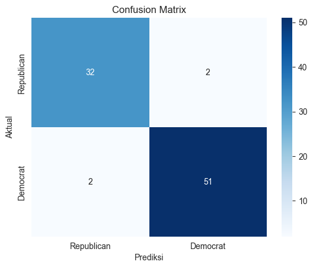

```python
# Pisahkan fitur (X) dan target (y)
X = df_transformed.drop('class_name', axis=1)
y = df_transformed['class_name']

# Bagi data menjadi data latih dan data uji (80% latih, 20% uji)
X_train, X_test, y_train, y_test = train_test_split(X, y, test_size=0.2, random_state=42, stratify=y)

# Latih model Logistic Regression
model_lr = LogisticRegression()
model_lr.fit(X_train, y_train)

# Buat prediksi
y_pred_lr = model_lr.predict(X_test)

# Evaluasi model
print("Akurasi Model Klasifikasi:", accuracy_score(y_test, y_pred_lr))
print("\nLaporan Klasifikasi:\n", classification_report(y_test, y_pred_lr, target_names=['Republican', 'Democrat']))

# Visualisasi Confusion Matrix
cm = confusion_matrix(y_test, y_pred_lr)
sns.heatmap(cm, annot=True, fmt='d', cmap='Blues', xticklabels=['Republican', 'Democrat'], yticklabels=['Republican', 'Democrat'])
plt.xlabel('Prediksi')
plt.ylabel('Aktual')
plt.title('Confusion Matrix')
plt.show()
```

## 6. Pemodelan - Clustering

Tujuan: Mengelompokkan legislator ke dalam beberapa cluster berdasarkan kesamaan pola voting, tanpa melihat label partainya.

### 6.1. Menentukan Jumlah Cluster (K) dengan Elbow Method

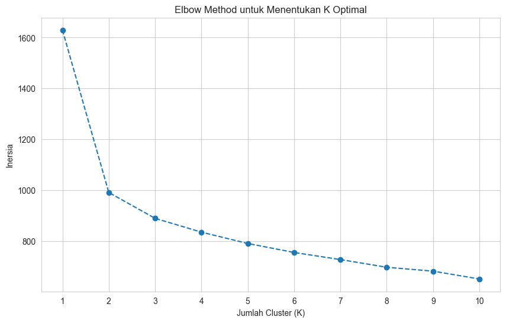

```python
# Gunakan semua data voting (X) untuk clustering
inertia = []
k_range = range(1, 11)

for k in k_range:
    kmeans = KMeans(n_clusters=k, random_state=42, n_init=10)
    kmeans.fit(X)
    inertia.append(kmeans.inertia_)

# Plot Elbow Curve
plt.figure(figsize=(10, 6))
plt.plot(k_range, inertia, marker='o', linestyle='--')
plt.xlabel('Jumlah Cluster (K)')
plt.ylabel('Inersia')
plt.title('Elbow Method untuk Menentukan K Optimal')
plt.xticks(k_range)
plt.show()
```

Analisis Elbow Method: "Siku" pada plot di atas (biasanya K=2 atau K=3 untuk dataset ini) menunjukkan jumlah cluster yang optimal. Untuk contoh ini, kita akan gunakan K=2.

### 6.2. Menerapkan K-Means dan Menganalisis Cluster

```python
# Terapkan K-Means dengan K=2
kmeans = KMeans(n_clusters=2, random_state=42, n_init=10)
kmeans.fit(X)

# Tambahkan label cluster ke dataframe asli (bukan yang ditransformasi)
df['cluster'] = kmeans.labels_

# Analisis hasil clustering dengan membandingkan cluster dan partai asli
print("Analisis Crosstab antara Partai Asli dan Hasil Cluster:")
crosstab = pd.crosstab(df['class_name'], df['cluster'])
display(crosstab)
```

```
Analisis Crosstab antara Partai Asli dan Hasil Cluster:
```

| cluster class_name | 0 | 1 |
| --- | --- | --- |
| democrat | 41 | 226 |
| republican | 157 | 11 |

Interpretasi Hasil Clustering: Tabel crosstab di atas menunjukkan komposisi partai di setiap cluster. Idealnya, satu cluster akan didominasi oleh Demokrat dan cluster lainnya oleh Republik, yang membuktikan bahwa pola voting memang sangat terikat dengan afiliasi partai. Ini juga bisa menunjukkan beberapa anggota yang "salah cluster" (misalnya, seorang Demokrat di cluster mayoritas Republik), yang merupakan legislator "maverick" yang menarik untuk dianalisis lebih lanjut.

## 7. Evaluasi Model Lanjutan

Pada tahap sebelumnya, kita sudah mendapatkan metrik evaluasi dasar. Sekarang kita akan melakukan evaluasi yang lebih robust untuk memastikan model kita benar-benar handal.

### 7.1. Evaluasi Model Klasifikasi (dengan K-Fold Cross-Validation)

Menggunakan satu train_test_split bisa menghasilkan akurasi yang "beruntung" atau "sial". K-Fold Cross-Validation adalah teknik yang lebih baik karena menguji model pada beberapa "lipatan" data yang berbeda dan mengambil rata-ratanya,

```python
from sklearn.model_selection import cross_val_score

# Kita akan menggunakan keseluruhan data (X dan y) dan model yang sama
# cross_val_score akan menangani pembagian data secara internal
print("Menjalankan 10-Fold Cross-Validation...")
# cv=10 berarti kita menggunakan 10 lipatan
scores = cross_val_score(model_lr, X, y, cv=10, scoring='accuracy')

print("\nHasil akurasi untuk setiap lipatan:")
print(scores)

# Tampilkan hasil rata-rata dan standar deviasi
print(f"\nRata-rata Akurasi (Cross-Validation): {scores.mean():.4f}")
print(f"Standar Deviasi Akurasi: {scores.std():.4f}")
```

```
Menjalankan 10-Fold Cross-Validation...

Hasil akurasi untuk setiap lipatan:
[0.97727273 0.93181818 0.97727273 0.93181818 1.         0.90697674
 1.         0.97674419 0.90697674 0.95348837]

Rata-rata Akurasi (Cross-Validation): 0.9562
Standar Deviasi Akurasi: 0.0335
```

### 7.2. Evaluasi Model Clustering (dengan Silhouette Score)

Untuk clustering, kita tidak punya "jawaban benar" sehingga tidak bisa menggunakan akurasi. Silhouette Score adalah metrik untuk mengukur seberapa baik sebuah titik data berada di dalam clusternya dibandingkan dengan cluster lain.

- Skor mendekati +1: Sangat baik, cluster padat dan terpisah jauh.
- Skor mendekati 0: Cluster tumpang tindih.
- Skor negatif: Titik data mungkin salah masuk cluster.

```python
from sklearn.metrics import silhouette_score

# Gunakan data X dan label cluster dari model K-Means sebelumnya
# Asumsi kita menggunakan K=2
cluster_labels = kmeans.labels_

silhouette_avg = silhouette_score(X, cluster_labels)

print(f"Silhouette Score untuk K=2 adalah: {silhouette_avg:.4f}")
```

```
Silhouette Score untuk K=2 adalah: 0.3470
```

## 8. Deployment Model

Sekarang, mari kita siapkan model klasifikasi kita agar bisa digunakan di dunia nyata. Model yang akan kita deploy adalah model klasifikasi (Logistic Regression) karena memiliki tujuan praktis: menerima 16 input suara dan memprediksi partai.

Langkah 1: Simpan Model yang Sudah Dilatih Kita hanya perlu menyimpan objek model yang sudah dilatih. Kita akan menggunakan joblib.

```python
import joblib

# Simpan model ke sebuah file
joblib.dump(model_lr, 'voting_classification_model.pkl')

print("Model berhasil disimpan sebagai 'voting_classification_model.pkl'")
```

```
Model berhasil disimpan sebagai 'voting_classification_model.pkl'
```

1. Instal Library:

```python
pip install streamlit scikit-learn joblib pandas
```

2. Buat file app.py:

```python
import streamlit as st
import pandas as pd
import joblib

# Muat model
model = joblib.load('voting_classification_model.pkl')

# Judul dan deskripsi aplikasi
st.title('Prediktor Afiliasi Partai Anggota Kongres 🏛️')
st.write("Pilih hasil voting untuk 16 isu kunci untuk memprediksi apakah seorang legislator adalah seorang Demokrat atau Republik.")

# Ambil nama-nama isu (tanpa 'class_name')
columns = [
    'handicapped_infants', 'water_project', 'budget_resolution', 'physician_fee_freeze',
    'el_salvador_aid', 'religious_groups_in_schools', 'anti_satellite_test_ban', 'aid_to_nicaraguan_contras',
    'mx_missile', 'immigration', 'synfuels_corporation_cutback', 'education_spending', 'superfund_right_to_sue',
    'crime', 'duty_free_exports', 'export_administration_act_south_africa'
]

# Buat form input
inputs = {}
with st.form("voting_form"):
    st.header("Pilihan Voting:")
    # Buat 2 kolom agar tidak terlalu panjang ke bawah
    col1, col2 = st.columns(2)

    for i, col_name in enumerate(columns):
        # Tampilkan di kolom 1 atau 2
        target_col = col1 if i < 8 else col2
        # Buat radio button untuk setiap isu
        vote = target_col.radio(
            label=col_name.replace("_", " ").title(),
            options=['y', 'n', '?'],
            captions=['Setuju (Yes)', 'Tidak Setuju (No)', 'Abstain'],
            horizontal=True,
            key=col_name
        )
        inputs[col_name] = vote

    # Tombol submit
    submitted = st.form_submit_button("Prediksi Sekarang")

# Jika tombol ditekan
if submitted:
    # Lakukan proses yang sama seperti di API
    input_df = pd.DataFrame([inputs])
    input_df.replace('?', 'y', inplace=True) # Simplifikasi: ganti abstain dengan 'yes'
    input_df.replace({'y': 1, 'n': 0}, inplace=True)

    prediction_code = model.predict(input_df)[0]
    prediction_proba = model.predict_proba(input_df)[0]

    party = 'Democrat' if prediction_code == 1 else 'Republican'
    confidence = prediction_proba[prediction_code]

    st.subheader('Hasil Prediksi:')
    if party == 'Democrat':
        st.success(f'Legislator ini kemungkinan besar adalah seorang **Democrat** dengan tingkat keyakinan {confidence:.2%}.')
    else:
        st.error(f'Legislator ini kemungkinan besar adalah seorang **Republican** dengan tingkat keyakinan {confidence:.2%}.')
```

3. Jalankan Aplikasi Streamlit:

Di terminal, jalankan perintah:

```python
streamlit run app.py
```